# Zadatak1 - linearna regresija

Marko Galavić

2026-06-10

## 1 Zadatak: Višestruka linearna regresija

U zaglavlju upišite svoje ime i prezime pod *author: “Ime i prezime”*.

U datoteci se nalazi skup podataka s kvantitativnom odzivnom varijablom `Y`, kvantitativnim prediktorima `X1`, `X2`, `X3`, `X4` i kvalitativnom varijablom `F1`.

1. Učitajte podatke i prikažite osnovni sažetak varijabli.
2. Prikažite barem dva prikladna grafička prikaza koji pokazuju povezanost odzivne varijable `Y` s prediktorima. Posebno komentirajte odnos `Y` s nekim kvantitativnim prediktorom i odnos `Y` s faktorom `F1`.
3. Izračunajte korelacije između kvantitativnih prediktora. Postoje li prediktori koji su jako korelirani?
4. Procijenite puni model
   $$Y \sim X1 + X2 + X3 + X4 + F1.$$
   Na temelju `summary()` funkcije komentirajte značajnost prediktora i vrijednosti $R^2$ i prilagođenog $R^2$.
5. Izračunajte VIF vrijednosti za puni model. Postoji li problem kolinearnosti? Koji su prediktori problematični?
6. Procijenite jednostavniji model u kojem izostavljate jedan od jako koreliranih prediktora. Usporedite modele pomoću prilagođenog $R^2$ i AIC-a.
7. Procijenite model s interakcijom
   $$Y \sim X1 + X3 \cdot F1.$$
   Komentirajte značenje interakcijskog člana.
8. Napišite procijenjenu jednadžbu odabranog modela i interpretirajte barem jedan koeficijent.
9. Pomoću odabranog modela izračunajte predikciju za prva tri opažanja u skupu podataka.
10. Prikažite dijagnostičke grafove reziduala za odabrani model i kratko komentirajte postoje li ozbiljni problemi s pretpostavkama linearne regresije.

## 2 Rješenje:

## 3 1. Učitavanje podataka i osnovni sažetak

```r
data <- read.csv("linreg_02.csv")

str(data)
```

```
## 'data.frame':    260 obs. of  6 variables:
##  $ Y : num  13.17 11.15 7.05 6.81 9.17 ...
##  $ X1: num  -0.854 -0.353 0.89 1.741 0.916 ...
##  $ X2: num  -0.358 -0.213 0.521 1.518 0.691 ...
##  $ X3: num  1.034 2.308 0.577 -1.434 0.788 ...
##  $ X4: num  -0.23 -1.818 1.632 1.103 0.335 ...
##  $ F1: chr  "A" "B" "B" "B" ...
```

```r
summary(data)
```

```
##        Y                X1                  X2                 X3
##  Min.   : 2.753   Min.   :-2.419800   Min.   :-2.34270   Min.   :-3.27250
##  1st Qu.: 9.294   1st Qu.:-0.611625   1st Qu.:-0.59510   1st Qu.:-0.61230
##  Median :11.202   Median : 0.018450   Median : 0.00945   Median : 0.07030
##  Mean   :11.185   Mean   : 0.008285   Mean   : 0.03044   Mean   : 0.05447
##  3rd Qu.:13.205   3rd Qu.: 0.635175   3rd Qu.: 0.67815   3rd Qu.: 0.75728
##  Max.   :18.579   Max.   : 3.030000   Max.   : 3.30800   Max.   : 2.30780
##        X4                F1
##  Min.   :-2.89700   Length:260
##  1st Qu.:-0.64815   Class :character
##  Median : 0.02535   Mode  :character
##  Mean   : 0.06058
##  3rd Qu.: 0.82098
##  Max.   : 2.97500
```

Skup podataka sadrži odzivnu varijablu `Y`, četiri kvantitativna prediktora (`X1`, `X2`, `X3`, `X4`) te faktor `F1`.

## 4 2. Grafički prikazi

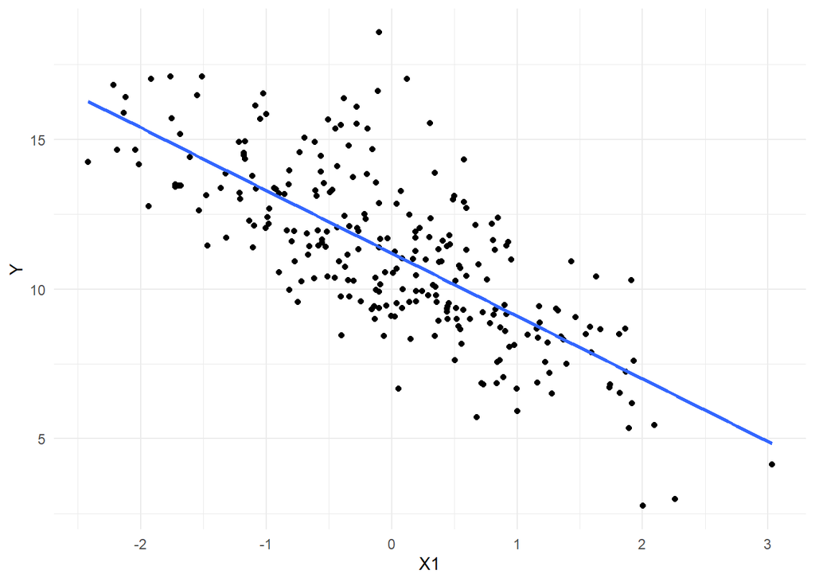

```r
library(ggplot2)

ggplot(data, aes(x = X1, y = Y)) +
  geom_point() +
  geom_smooth(method = "lm", se = FALSE) +
  theme_minimal()
```

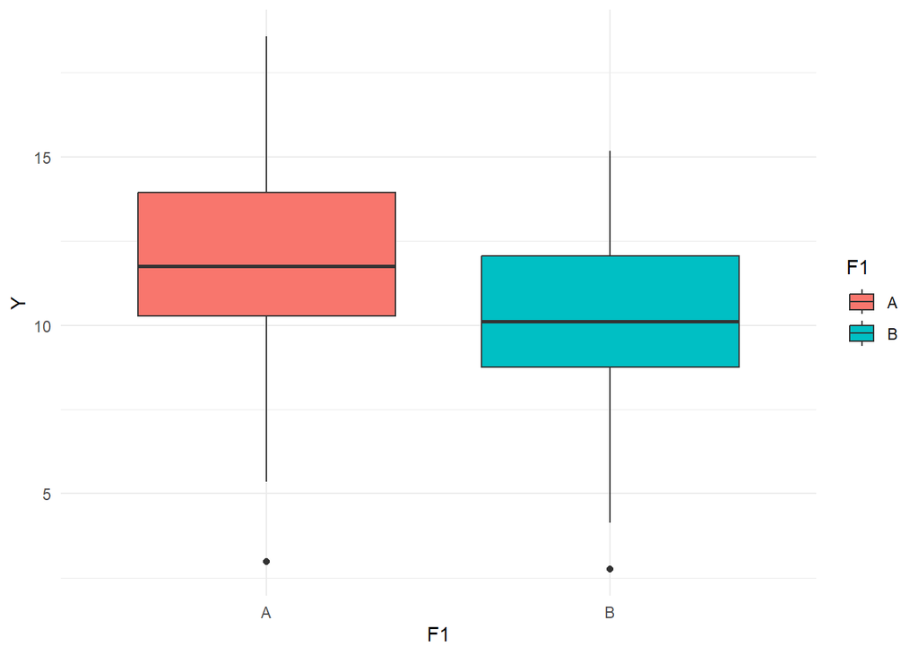

```r
ggplot(data, aes(x = F1, y = Y, fill = F1)) +
  geom_boxplot() +
  theme_minimal()
```

Na prvom grafu vidi se negativna povezanost između varijabli `Y` i `X1`. Veće vrijednosti `X1` uglavnom su povezane s manjim vrijednostima odzivne varijable.

Boxplot pokazuje razliku između razina faktora `F1`. Čini se da skupina A ima veće prosječne vrijednosti odziva `Y` od skupine B.

## 5 3. Korelacije kvantitativnih prediktora

```r
cor(data[, c("X1", "X2", "X3", "X4")])
```

```
##             X1          X2          X3          X4
## X1  1.00000000  0.96195898 -0.01939870 -0.05267379
## X2  0.96195898  1.00000000 -0.02789888 -0.04333809
## X3 -0.01939870 -0.02789888  1.00000000 -0.16343168
## X4 -0.05267379 -0.04333809 -0.16343168  1.00000000
```

Najveća korelacija javlja se između `X1` i `X2`: Radi se o vrlo jakoj pozitivnoj korelaciji, što može uzrokovati problem multikolinearnosti.

## 6 4. Puni model

```r
model_full <- lm(Y ~ X1 + X2 + X3 + X4 + F1, data = data)

summary(model_full)
```

```
##
## Call:
## lm(formula = Y ~ X1 + X2 + X3 + X4 + F1, data = data)
##
## Residuals:
##     Min      1Q  Median      3Q     Max
## -3.3353 -1.0155 -0.0853  0.8561  4.2533
##
## Coefficients:
##             Estimate Std. Error t value Pr(>|t|)
## (Intercept) 11.98534    0.12145  98.682  < 2e-16 ***
## X1          -1.83169    0.32082  -5.709 3.16e-08 ***
## X2          -0.28848    0.32654  -0.883    0.378
## X3           0.95231    0.08917  10.680  < 2e-16 ***
## X4          -0.02131    0.08367  -0.255    0.799
## F1B         -1.65385    0.17297  -9.562  < 2e-16 ***
## ---
## Signif. codes:  0 '***' 0.001 '**' 0.01 '*' 0.05 '.' 0.1 ' ' 1
##
## Residual standard error: 1.377 on 254 degrees of freedom
## Multiple R-squared:  0.7626, Adjusted R-squared:  0.7579
## F-statistic: 163.2 on 5 and 254 DF,  p-value: < 2.2e-16
```

Dobiveni rezultati pokazuju:

- značajne prediktore: `X1`, `X3` i `F1`
- neznačajne prediktore: `X2` i `X4`

Vrijednosti koeficijenta determinacije su približno:

- $R^2 = 0.763$
- prilagođeni $R^2 = 0.758$

Model objašnjava oko 76 % varijabilnosti odzivne varijable.

## 7 5. VIF analiza

```r
library(car)

vif(model_full)
```

```
##        X1        X2        X3        X4        F1
## 13.719660 13.705357  1.032117  1.031230  1.025443
```

VIF vrijednosti za `X1` i `X2` iznose približno:

- VIF(X1) = 13.7
- VIF(X2) = 13.7

Budući da su veće od 10, postoji ozbiljan problem multikolinearnosti između tih prediktora.

## 8 6. Jednostavniji model

Zbog vrlo visoke korelacije izostavljamo varijablu `X2`.

```r
model_red <- lm(Y ~ X1 + X3 + X4 + F1, data = data)

summary(model_red)
```

```
##
## Call:
## lm(formula = Y ~ X1 + X3 + X4 + F1, data = data)
##
## Residuals:
##     Min      1Q  Median      3Q     Max
## -3.4125 -0.9891 -0.0705  0.8562  4.2603
##
## Coefficients:
##             Estimate Std. Error t value Pr(>|t|)
## (Intercept) 11.98985    0.12130  98.849   <2e-16 ***
## X1          -2.10455    0.08677 -24.256   <2e-16 ***
## X3           0.95402    0.08911  10.707   <2e-16 ***
## X4          -0.02290    0.08362  -0.274    0.784
## F1B         -1.67589    0.17108  -9.796   <2e-16 ***
## ---
## Signif. codes:  0 '***' 0.001 '**' 0.01 '*' 0.05 '.' 0.1 ' ' 1
##
## Residual standard error: 1.377 on 255 degrees of freedom
## Multiple R-squared:  0.7619, Adjusted R-squared:  0.7581
## F-statistic: 203.9 on 4 and 255 DF,  p-value: < 2.2e-16
```

```r
AIC(model_full)
```

```
## [1] 912.1665
```

```r
AIC(model_red)
```

```
## [1] 910.9642
```

### 8.1 Usporedba modela

Reducirani model ima gotovo identičan prilagođeni $R^2$, ali manji AIC, pa je poželjniji.

## 9 7. Model s interakcijom

```r
model_int <- lm(Y ~ X1 + X3 * F1, data = data)

summary(model_int)
```

```
##
## Call:
## lm(formula = Y ~ X1 + X3 * F1, data = data)
##
## Residuals:
##     Min      1Q  Median      3Q     Max
## -2.9684 -0.8651 -0.1557  0.8720  3.8577
##
## Coefficients:
##             Estimate Std. Error t value Pr(>|t|)
## (Intercept)  11.9207     0.1107  107.68  < 2e-16 ***
## X1           -2.0869     0.0789  -26.45  < 2e-16 ***
## X3            1.5645     0.1157   13.52  < 2e-16 ***
## F1B          -1.6090     0.1560  -10.31  < 2e-16 ***
## X3:F1B       -1.1632     0.1602   -7.26 4.69e-12 ***
## ---
## Signif. codes:  0 '***' 0.001 '**' 0.01 '*' 0.05 '.' 0.1 ' ' 1
##
## Residual standard error: 1.253 on 255 degrees of freedom
## Multiple R-squared:  0.8026, Adjusted R-squared:  0.7995
## F-statistic: 259.2 on 4 and 255 DF,  p-value: < 2.2e-16
```

Interakcijski član `X3:F1` ispituje razlikuje li se učinak varijable `X3` između skupina A i B.

Procijenjeni koeficijent interakcije iznosi približno:

$$\hat{\beta}_{X3:F1B} = -1.16$$

To znači da je utjecaj varijable `X3` na odziv slabiji u skupini B nego u skupini A.

## 10 8. Procijenjena jednadžba odabranog modela

Odabrani model je reducirani model:

```r
coef(model_red)
```

```
## (Intercept)          X1          X3          X4         F1B
##  11.9898475  -2.1045541   0.9540229  -0.0229002  -1.6758922
```

Procijenjena jednadžba glasi:

$$\hat Y =
11.99
-2.10X_1
+0.95X_3
-0.02X_4
-1.68I(F1=B)$$

Koeficijent uz `X1` iznosi približno -2.10.

Ako se vrijednost `X1` poveća za jednu jedinicu, očekivana vrijednost odziva `Y` smanjuje se za približno 2.10 jedinica uz nepromijenjene ostale prediktore.

## 11 9. Predikcija za prva tri opažanja

```r
predict(model_red, newdata = data[1:3, ])
```

```
##         1         2         3
## 14.778547 13.299979  8.953876
```

Dobivene predikcije su približno za opažanje 1 je 14.78, za opažanje 2 je 13.30 i za opažanje 3 je 8.95.

## 12 10. Dijagnostički grafovi

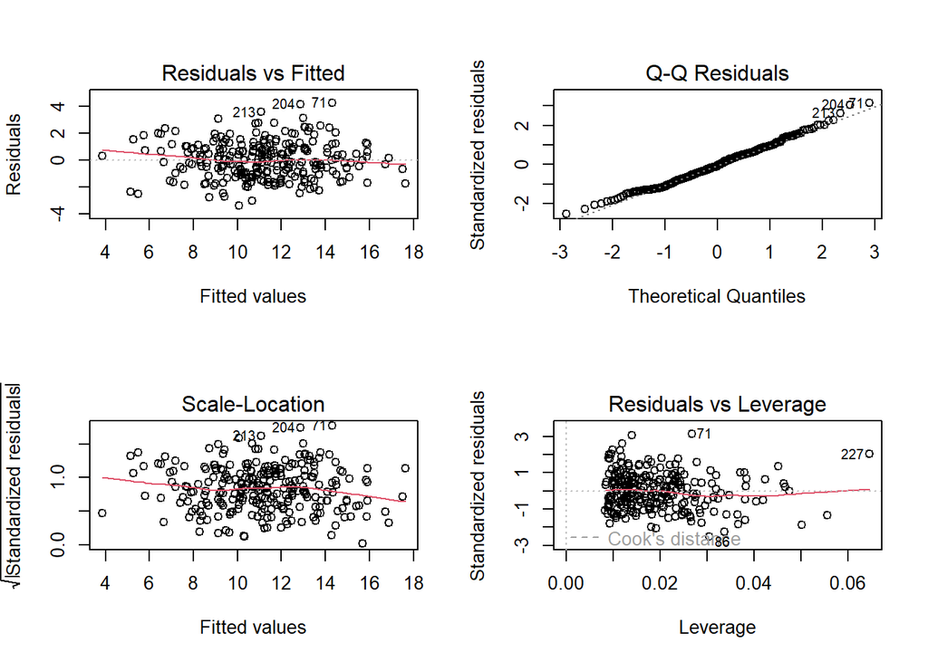

```r
par(mfrow = c(2,2))
plot(model_red)
```

Na temelju dijagnostičkih grafova: reziduali nemaju izražen obrazac, normalnost reziduala izgleda zadovoljavajuće, nema ozbiljnih odstupanja od homoskedastičnosti i nema velikog broja utjecajnih opažanja. Ne uočavaju se ozbiljna kršenja pretpostavki linearne regresije.